# Flight Delays Prediction / Analytics

### Ploting the results

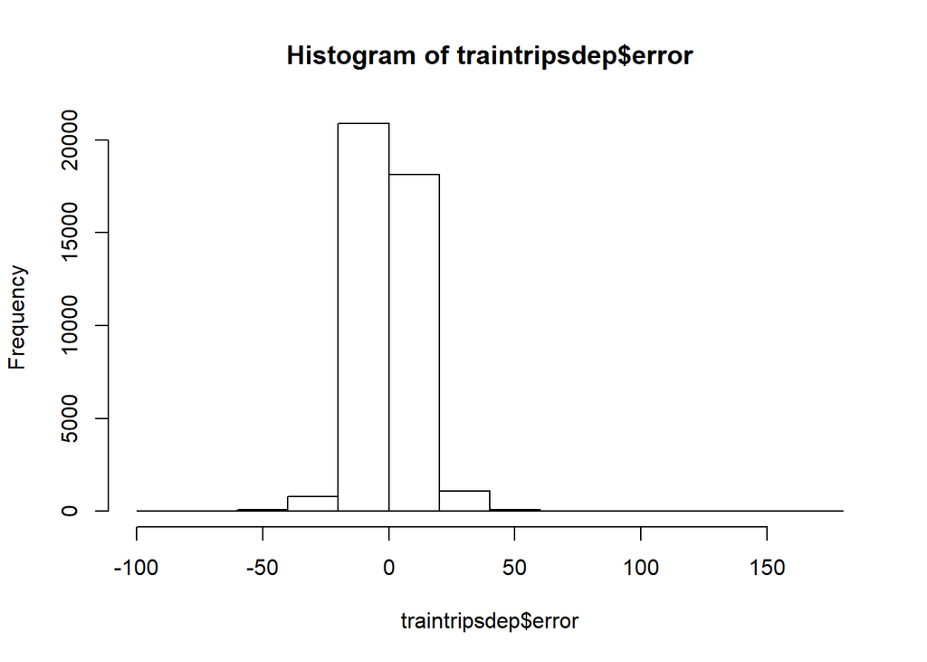

```r
# Check residual plots
hist(traintripsdep$error)
```

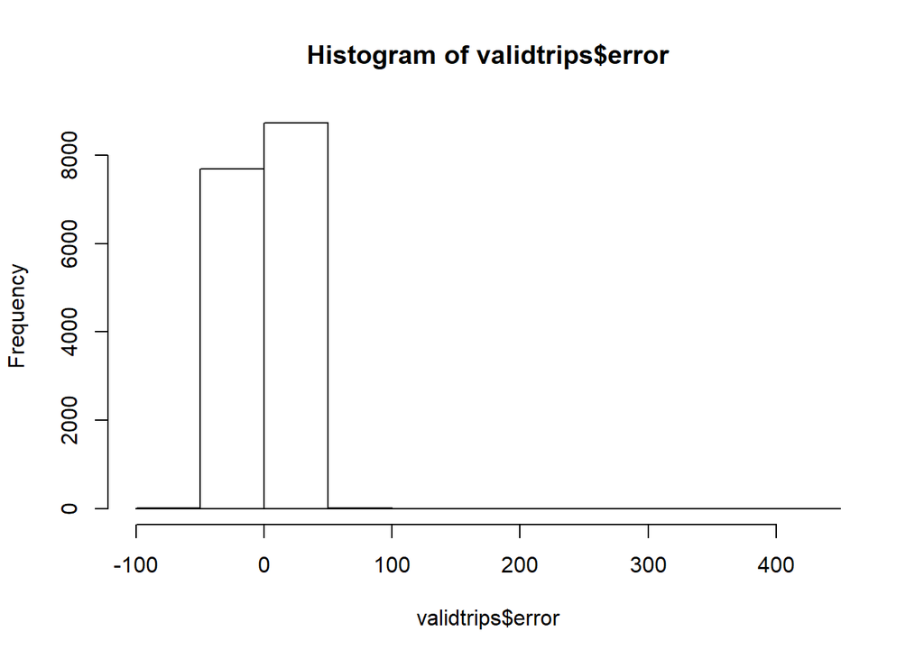

```r
hist(validtrips$error)
```

In both cases the histogram is centered at zero. Espicially with Test data. This is a good test. Follows nornal distribution which is a good measure of model performance.

#### Corelation

```r
# Correlation
a<-cor(traintripsdep$DepDelay,
       traintripsdep$pred.DepDelay )
b<-cor(validtrips$DepDelay,
       validtrips$predict.DepDelay )
a
```

```
## [1] 0.9703989
```

```r
b
```

```
## [1] 0.9669946
```

```r
a*a
```

```
## [1] 0.941674
```

```r
b*b
```

```
## [1] 0.9350786
```

#### Corelation between actul and predicted is very high satisfying the accuracy of the model.

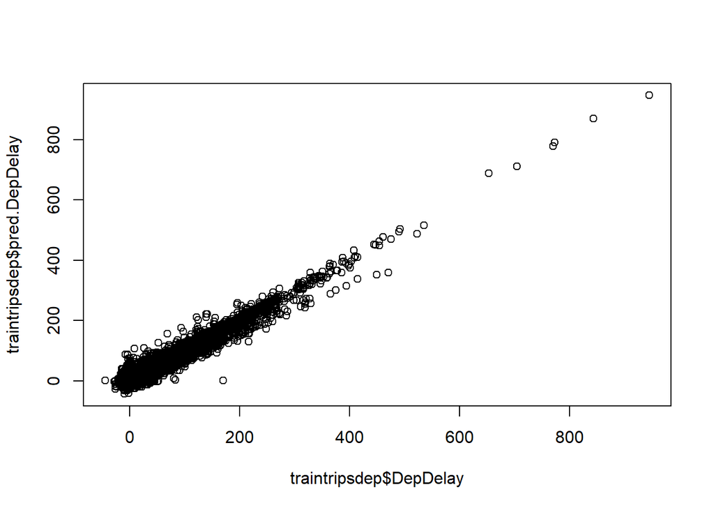

```r
plot(traintripsdep$DepDelay,
     traintripsdep$pred.DepDelay )
```

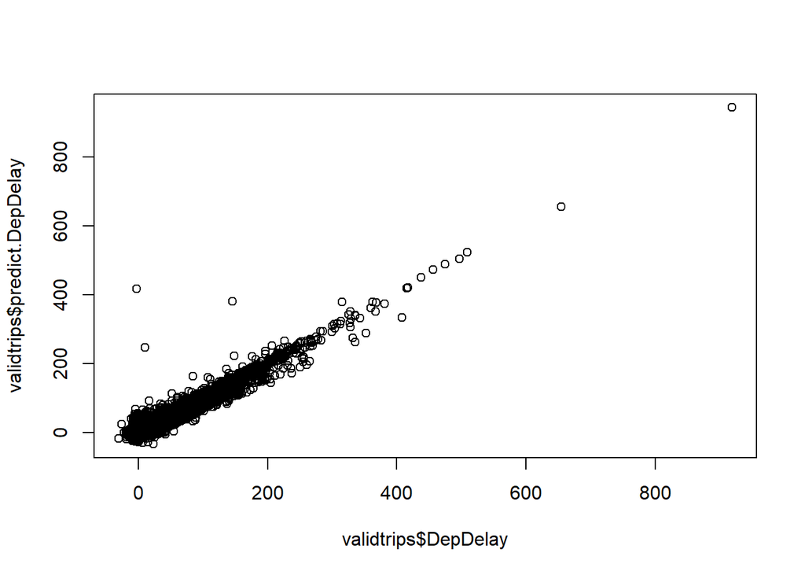

```r
plot(validtrips$DepDelay,
     validtrips$predict.DepDelay )
```

If we look at the Actual vs Predicted it almost follows stright line over diaognal.

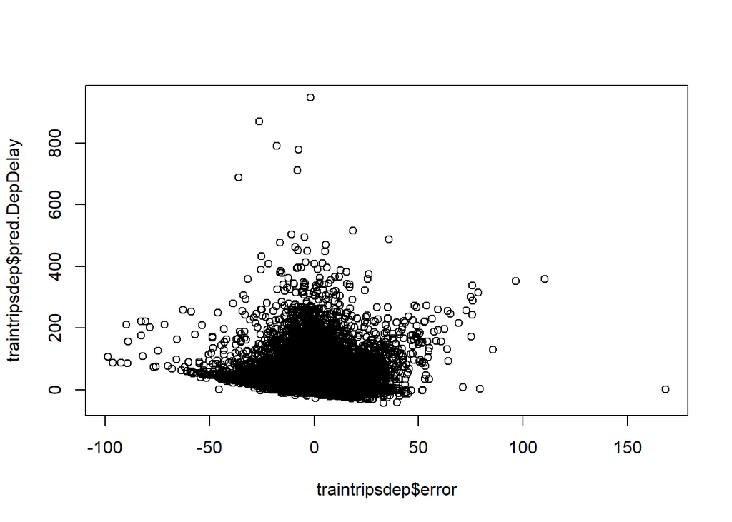

```r
plot(traintripsdep$error,
     traintripsdep$pred.DepDelay )
```

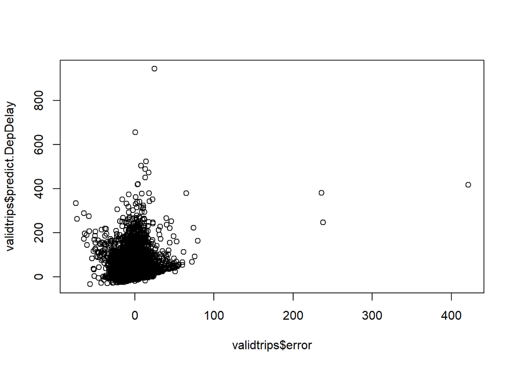

```r
plot(validtrips$error,
     validtrips$predict.DepDelay )
```

Follows normal distributuon. Model performance is good and accuracy is good as well.

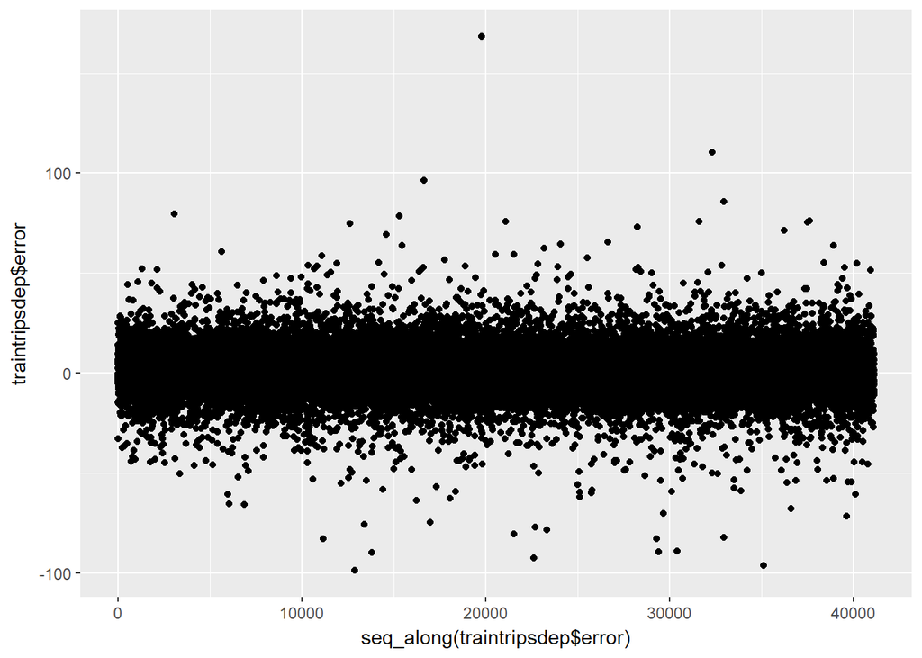

```r
qplot(y=traintripsdep$error)
```

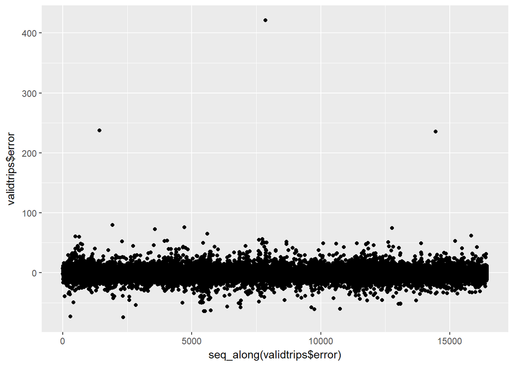

```r
qplot(y=validtrips$error)
```

There are very few outliers which is good as well.

#### regularization: I don’t think it is needed here as co-efficients are not very large. We are not getting any additional benifit.

```r
fitControl <- trainControl(method = "cv", number = 10)  # Cross validation

#ridge.dep.fit1 <- train(DepDelay ~ ., data=traintripsdep, method ='ridge', trControl=fitControl, preProcess= c("scale", "center"))

#lasso.dep.fit2 <- train(DepDelay ~ . , data=traintripsdep, method ='lasso', trControl=fitControl, preProcess= c("scale", "center"))

#summary(ridge.dep.fit1)
#summar(lasso.dep.fit2)
```

###### Let us see if we are able to get any advantage by doing Principal component analysis:

```r
# First remove predictor variable Depdelay and apply

prcomptrainDepdelayvar <- traintripsdep[, grepl("Depdelay" , names(traintrips))]

prcomptraindepdelaydata <- traintripsdep[, !grepl("DepDelay" , names(traintrips))]

prin_comp <- prcomp(prcomptraindepdelaydata )

#compute standard deviation of each principal component
std_dev <- prin_comp$sdev

#compute variance
pr_var <- std_dev^2

#check variance of first 10 components

pr_var[1:10]
```

```
##  [1] 1745.1481935   95.1778812    1.4035445    1.0061286    0.9473854
##  [6]    0.5790285    0.2318861    0.2300109    0.1755183    0.1524797
```

```r
#proportion of variance explained
prop_varex <- pr_var/sum(pr_var)
prop_varex[1:20]
```

```
##  [1] 9.427735e-01 5.141752e-02 7.582305e-04 5.435363e-04 5.118017e-04
##  [6] 3.128060e-04 1.252708e-04 1.242577e-04 9.481948e-05 8.237343e-05
## [11] 8.156619e-05 7.919850e-05 7.791841e-05 7.724633e-05 7.158367e-05
## [16] 6.790961e-05 6.735530e-05 6.311755e-05 6.079266e-05 5.737874e-05
```

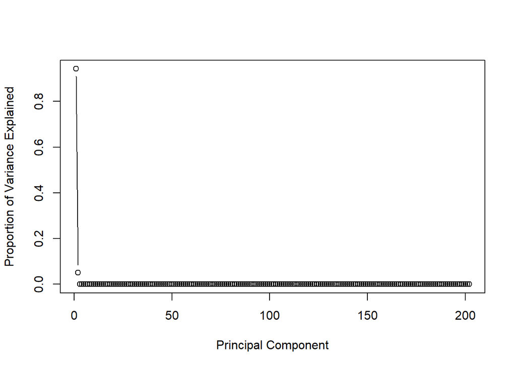

```r
#scree plot
plot(prop_varex, xlab = "Principal Component",
             ylab = "Proportion of Variance Explained",
             type = "b")
```

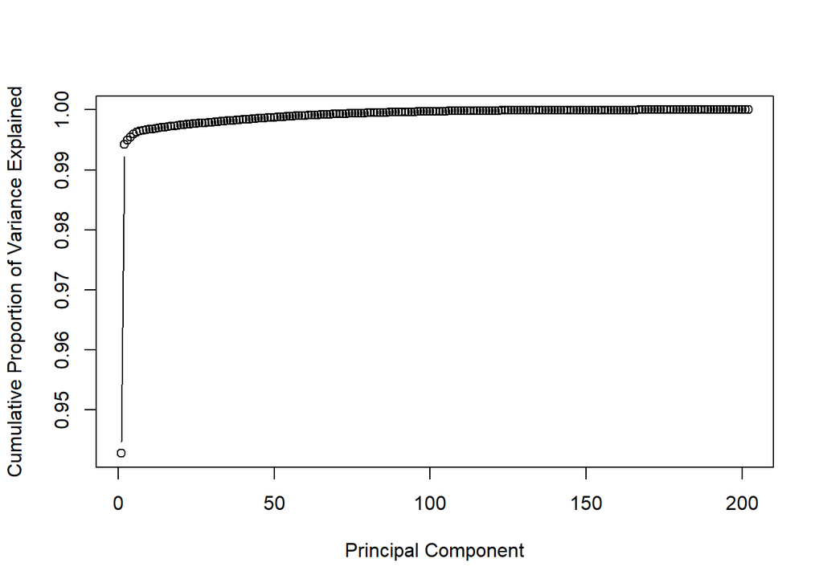

```r
#cumulative scree plot
plot(cumsum(prop_varex), xlab = "Principal Component",
              ylab = "Cumulative Proportion of Variance Explained",
              type = "b")
```